# Lab session 2 - Bayesian Statistics

April, 12 2019

**1** In each of the following cases, construct an *Accept–Reject* algorithm, generate a sample of the corresponding random variables, and draw the density function on top of the histogram. Compute the acceptance probability.

- A-R algorithm:
- Generate $Y \sim g$, with $g$ candidate density, and, independently, $U \sim U_{[0,1]}$;
- Accept $X=Y$ if $U \le f(Y)/cg(Y)$, discard $Y$ and $U$ otherwise;

Remember to check that $f$ and $g$ have compatible support and that the constant $c$ is defined as

$$c : \frac{f(x)}{g(x)} \le c, \quad \forall x$$

- Generate normal random variables using a Cauchy candidate in Accept–Reject algorithm.
- Generate gamma $\mathcal{G}(4.3, 6.2)$ random variables using a gamma $\mathcal{G}(4, 7)$ candidate.

**2** Student’s $t$ density with $\nu$ degrees of freedom, is given by

$$f(x|\nu)= \frac{\Gamma\left(\frac{\nu+1}{2}\right)}{\Gamma\left(\frac{\nu}{2}\right)} \frac{1}{\sqrt{\nu \pi}}(1+x^2/\nu)^{(\nu+1)/2}$$

Calculate the mean of a t distribution with $\nu = 4$ degrees of freedom using a Metropolis–Hastings algorithm with candidate density

- $N(0,1)$
- $t$ with $\nu= 2$ degrees of freedom.

Monitor the convergence across iterations and compute the acceptance rate.

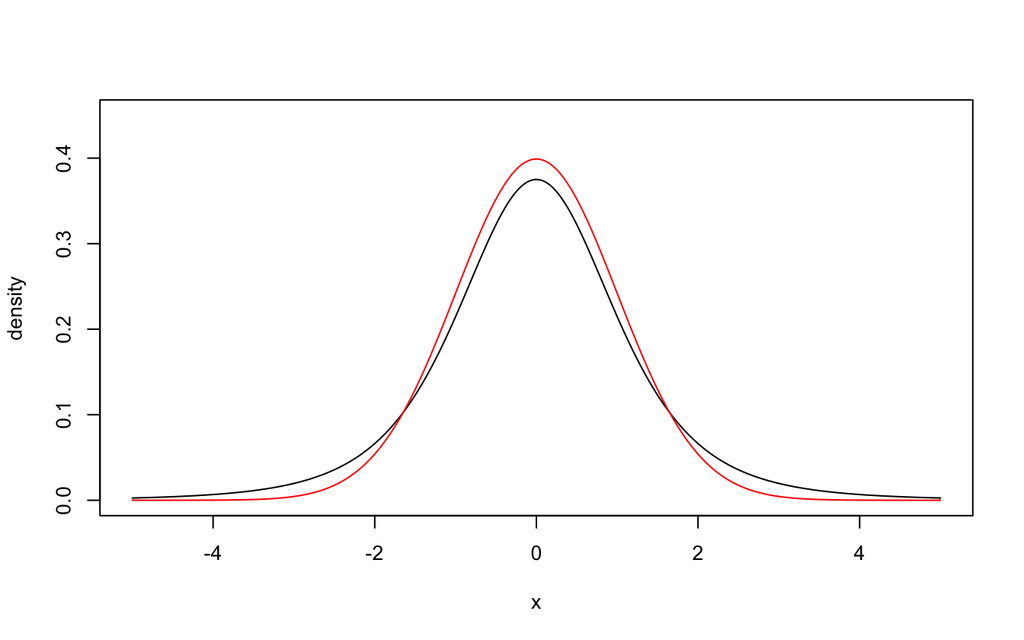

**3** Consider the *probit* model defined as
$$\begin{align*}
y_i &\sim Bernoulli(p_i)\\
p_i &= \Phi(x^T_i\beta)
\end{align*}$$

where $y_i \in {0,1}$ is the binary response variable, $x_i \in \mathbb{R}^{q+1}$ is the vector of covariates and $\Phi$ is the cdf of the standard normal distribution. Our aim is to estimate the vector of coefficients $\beta$.

- Load the dataset $\texttt{bank}$ from the package $\texttt{gclus}$. The first column is the response variable which describes the status of the banknotes: 0 = genuine, 1 = counterfeit. Then, select the following 4 columns as independent variables: Length, Left, Right, Bottom (remember to add a column for the intercept).

```r
library(gclus)
data(bank)
bank <- as.matrix(bank)

y <- bank[,1]
X <- cbind(1,bank[,2:5])
q <- dim(X)[2]
n <- dim(X)[1]
```

- Set a flat prior distribution on the parameters $\beta$, that is $\pi(\beta)\propto 1$. What is the posterior distribution? Write the function of the posterior distribution.
- Implement the following random walk Metropolis-Hastings algorithm:
  - Initialize $\beta^{(0)}=\hat{\beta}$
  - For N iterations repeat the following steps
  - Generate $\beta' \sim N_{q+1}(\beta^{(k-1)}, \tau^2\hat\Sigma)$
  - Compute the acceptance probability as
    $$\alpha(\beta^{(k-1)},\beta')=\min\left(1, \frac{\pi(\beta'|y)}{\pi(\beta^{(k-1)}|y)}\right)$$
  - Generate $U \sim U(0,1)$: if $U < \alpha(\beta^{(k-1)},\beta')$, $\beta^{(k)}=\beta$, otherwise $\beta^{(k)}=\beta^{(k-1)}$.
- Simulate 10000 iterations using different values of $\tau= 0.1, 1, 4$. Then plot the trace of the parameters, the autocorrelation and the histogram. Which value of $\tau$ seems the best?
- Using the selected simulations, give a Monte Carlo estimate of the posterior mean and variance of $\beta$ (burn-in=1000 and thin=10). Compare the posterior estimates with the ones obtained using the function $\texttt{glm}$.